# Multinomial Logit Regression

https://bookdown.org/sarahwerth2024/CategoricalBook/multinomial-logit-regression-r.html

### Equations

logistic regression equation is as follows: $ln(\frac{P}{1-P}) = \beta_0 + \beta_1X_1 +...\beta_kX_k$

The logistic regression coefficient β associated with a predictor X is the expected change in log odds of having the outcome per unit change in X. So increasing the predictor by 1 unit (or going from 1 level to the next) multiplies the odds of having the outcome by eβ.

Multinomial Logit Regression is used for categorical outcome variable with **more than two categories**. The most complicated part of is the interpretation. stacking two or more logistic regressions on top of each other. outcome, instead of being the log odds, becomes the **log odds of the probability of one category over the probability of the base category**. Let’s say category A is the base category. I am going to refer to probability as P. Our outcome is now the natural log of this ratio (still log-odds, just with a ratio now). This is called the **relative log-odds**: $ln(\frac{P_categiryB}{P_categoroyA})$.

So if we had three categories in our outcome: **Category A, Category B, and Category C**. We decide that Category **A is** our **base** category, and then we have two equations: one for Category B and one for Category C.

$$ln(\frac{P_categiryB}{P_categoroyA})=\beta_0 + \beta_1X_1 +...\beta_kX_k$$

$$ln(\frac{P_categiryC}{P_categoroyA})=\beta_0 + \beta_1X_1 +...\beta_kX_k$$

We have four options for interpreting coefficients in multinomial logistic regression. They are pretty much the same as logistic regression, just formatted as a comparison from the base category to another category.

1. **Relative Log Odds**: This is equivalent to log-odds in the logistic regression. This is the default output in R. *A one-unit change in X is associated with a [blank] change in the log odds of being in category B compared to the base category.*
2. **Relative Risk Ratios**: This is equivalent to odds ratios in logistic regression. It’s calculated by exponentiating the coefficient ($e^\beta$). It is very common to refer to odds here as “risk,” but they are interchangeable. *A one-unit change in X is associated with a [blank] change in the”risk” of being in category B compared to the base category.*
3. **Predicted Probabilities**: The same thing as logistic regression, but it’s the probability of falling in a specific category. R will calculate this for you using the margins command you should be familiar with. Again, R is plugging in values for the covarites into the equation, and calculating a predicted value in terms of the probability of the outcome (or in this case being in a given category). *An observation with these values has a [blank] predicted probability of being in [blank] category.* We no longer have to reference the base category for the outcome. R will produce a predicted probability for being in each category in our analysis, BUT if your independent variable is categorical it won’t produce predicted probabilities for the base category for that variable
4. Marginal Effects: The same thing as logistic regression, but it’s the change in probability of falling into a specific category. R will calculate this for you using the margins command you should be familiar with and the dydx() option. *A one unit change in X is associated with a [blank] change in the probability of being in [blank] category.*

### Assumptions

1. Independence of irrelevant alternatives (IIA)

This assumption states that the relative likelihood of being in one category compared to the base category would not change if you added any other categories. Remember that multinomial logistic regression almost stacks two logistic regressions in one model. This assumption extends from that and the relative independence of those two stacked regressions. **The likelihood of being in category B compared to base category A should not change whether or not category C is an option.** Here’s a practical example offered by Benson(2016): A man asks his date if she wants to go to a rock concert or a classical music concert. She chooses classical music, but when he adds that jazz is also an option she says she’d actually like jazz the best. Jazz is a relevant alternative and would violate the IIA assumption. Remember this is particularly important if two of the options are relatively similar and another option is quite different. The relative similarity of options A and B obscure the big difference between options A and C. There are not good statistical tests to address this problem, so you are going to have to rely on your knowledge of the variables in the dataset. You have to make a judgment call whether you think two categories are too similar and try your best to **make each category is a unique option**.

2. The outcome is categorical

A categorical variable appropriate for multinomial logistic regression has three or more possible response categories. Technically you can run this model for ordered or unordered categorical variables, but other models are recommended for ordinal outcome variables.

3. The log-odds of the outcome and independent variable have a linear relationship

Like normal logistic regression, the log-odds of the outcome vs the any continuous explanatory variables should have a linear relationship. Like a linear regression, you can play around with squared and cubed terms to see if they address the curved relationship in your data.

4. Errors are independent

Like linear regression we don’t want to have obvious clusters in our data. Examples of clusters would be multiple observations from the same person at different times, multiple observations withing schools, people within cities, and so on. If you have a variable identifying the cluster (e.g., year, school, city, person), you can run a logistic regression adjusted for clustering **using cluster-robust standard errors** (rule of thumb is to have 50 clusters for this method). However, you may also want to consider learning about and applying a hierarchical linear model.

5. No severe multicolinearity

This is another carryover from linear regression. Multicollineary can throw a wrench in your model when one or more independent variables are correlated to one another. Run a **VIF (variance inflation factor)** to detect correlation between your independent variables. Consider dropping variables or combining them into one factor variable.

### Example in R

#### 0. Prepare Dataset

We will be running a multinomial logistic regression to see what characteristics are associated with the types of cultural grievances expressed by ethnocultural groups at risk. We will use the variable ‘culgrieve’ as our outcome, which represents the level of cultural grievances expressed by ethnic groups at risk. This variable has three values (the outcomes for our multinomial): 0 - No Grievances Expressed 没有表达不满 1 - Ending Discrmination 结束歧视 2 - Creating/Strengthening Remedial Policies 制定/加强补救政策

```r
df %>% select(culgrieve,legisrep,execrep,grplang,trsntlkin) %>% skim()
```

```
── Data Summary ────────────────────────
                           Values
Name                       Piped data
Number of rows             852
Number of columns          5
_______________________
Column type frequency:
  numeric                  5
________________________
Group variables            None
```

|  | skim_variable | n_missing | complete_rate | mean | sd | p0 | p25 | p50 | p75 | p100 | hist |
| --- | --- | --- | --- | --- | --- | --- | --- | --- | --- | --- | --- |
| 1 | culgrieve | 4 | 0.9953052 | 0.5707547 | 0.7139649 | 0 | 0 | 0 | 1 | 2 | ▇▁▅▁▂ |
| 2 | legisrep | 22 | 0.9741784 | 0.6373494 | 0.4810550 | 0 | 0 | 1 | 1 | 1 | ▅▁▁▁▇ |
| 3 | execrep | 6 | 0.9929577 | 0.4030733 | 0.4908054 | 0 | 0 | 0 | 1 | 1 | ▇▁▁▁▆ |
| 4 | grplang | 0 | 1.0000000 | 0.9753521 | 0.6020747 | 0 | 1 | 1 | 1 | 2 | ▂▁▇▁▂ |
| 5 | trsntlkin | 0 | 1.0000000 | 1.5352113 | 0.9585681 | 0 | 1 | 1 | 2 | 3 | ▂▇▁▅▃ |

```r
# Set categorical variables as factors
df_MAR <- df_MAR %>%
  mutate(
    culgrieve = factor(culgrieve,
                       labels = c("No Grievances Expressed",
                                  "Ending Discrimination",
                                  "Creating/Strengthening Remedial Policies")),
    legisrep = factor(legisrep,
                      labels = c("No", "Yes")),
    execrep = factor(execrep,
                      labels = c("No", "Yes")),
    grplang = factor(grplang,
                     labels = c("<10% Speak Native Lang",
                                "Some Speak Native Lang",
                                "Most Speak Native Lang")),
    trsntlkin = factor(trsntlkin,
                       labels = c("No Close Kindred",
                                  "Close Kindred/Not Adjoining Base",
                                  "Close Kindred, Adjoining Base",
                                  "Close Kindred, More than 1 Country")),
  )
```

#### 1. Plot your outcome and key independent variable

We’ll plot two plots instead of one in order to look at our two stacked regressions separately.

**Category 0 compared to Category 1**, **Category 0 compared to Category 2**

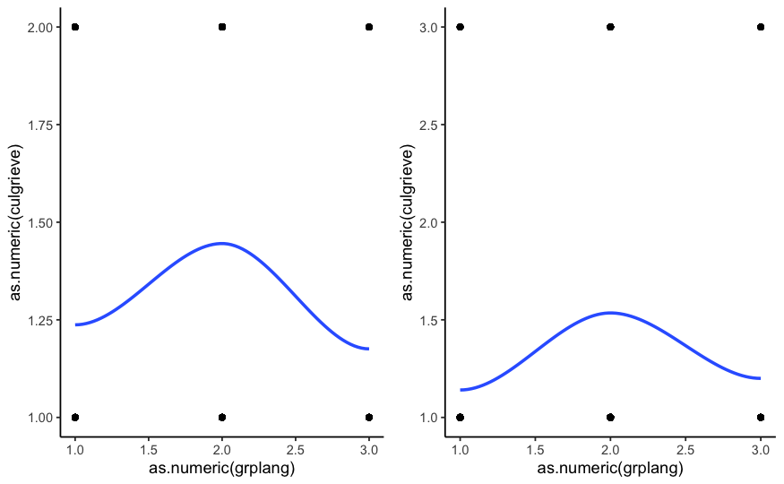

```r
library(gridExtra)
plot1 <- ggplot(df_MAR %>% filter(culgrieve == "No Grievances Expressed" |
                           culgrieve == "Ending Discrimination"),
       aes(x = as.numeric(grplang), y = as.numeric(culgrieve))) +
  geom_point() +
  geom_smooth(method = "loess", se = FALSE) +
  theme_classic()

plot2 <- ggplot(df_MAR %>% filter(culgrieve == "No Grievances Expressed" |
                        culgrieve == "Creating/Strengthening Remedial Policies"),
       aes(x = as.numeric(grplang), y = as.numeric(culgrieve))) +
  geom_point() +
  geom_smooth(method = "loess", se = FALSE) +
  theme_classic()
grid.arrange(plot1, plot2, ncol=2)
```

#### 2. Run simple model

we’ll use the multinom() function from the nnet package.

**First run a basic model with your outcome and key independent variable.**

```r
summary(fit_basic)
```

```
Call:
multinom(formula = culgrieve ~ grplang, data = df_MAR)

Coefficients:
                                         (Intercept) grplangSome Speak Native Lang grplangMost Speak Native Lang
Ending Discrimination                      -1.168166                     0.9489541                    -0.3786253
Creating/Strengthening Remedial Policies   -2.581645                     1.5751415                     0.3837751

Std. Errors:
                                         (Intercept) grplangSome Speak Native Lang grplangMost Speak Native Lang
Ending Discrimination                      0.1882289                     0.2108233                     0.2969347
Creating/Strengthening Remedial Policies   0.3456718                     0.3667327                     0.4605736

Residual Deviance: 1551.835
AIC: 1563.835
```

| y.level | term | estimate | std.error | statistic | p.value | conf.low | conf.high |
| --- | --- | --- | --- | --- | --- | --- | --- |
| Ending Discrimination | (Intercept) | -1.1681661 | 0.1882289 | -6.2060925 | 5.431821e-10 | -1.5370880 | -0.7992442 |
| Ending Discrimination | grplangSome Speak Native Lang | 0.9489541 | 0.2108233 | 4.5011826 | 6.757640e-06 | 0.5357480 | 1.3621601 |
| Ending Discrimination | grplangMost Speak Native Lang | -0.3786253 | 0.2969347 | -1.2751132 | 2.022692e-01 | -0.9606066 | 0.2033559 |
| Creating/Strengthening Remedial Policies | (Intercept) | -2.5816451 | 0.3456718 | -7.4684865 | 8.112246e-14 | -3.2591494 | -1.9041409 |
| Creating/Strengthening Remedial Policies | grplangSome Speak Native Lang | 1.5751415 | 0.3667327 | 4.2950667 | 1.746408e-05 | 0.8563585 | 2.2939244 |
| Creating/Strengthening Remedial Policies | grplangMost Speak Native Lang | 0.3837751 | 0.4605736 | 0.8332545 | 4.047012e-01 | -0.5189327 | 1.2864828 |

#### 3. Run full model

| y.level | term | estimate | std.error | statistic | p.value | conf.low | conf.high |
| --- | --- | --- | --- | --- | --- | --- | --- |
| Ending Discrimination | (Intercept) | 0.09565168 | 0.377526959 | -6.21688580 | 5.071186e-10 | 0.045639522 | 0.20046758 |
| Ending Discrimination | grplangSome Speak Native Lang | 3.14735067 | 0.242276073 | 4.73245677 | 2.218186e-06 | 1.957579310 | 5.06023749 |
| Ending Discrimination | grplangMost Speak Native Lang | 0.56274299 | 0.329260446 | -1.74613219 | 8.078798e-02 | 0.295150206 | 1.07294409 |
| Ending Discrimination | trsntlkinClose Kindred/Not Adjoining Base | 3.67966992 | 0.301576208 | 4.32004588 | 1.559968e-05 | 2.037542750 | 6.64524498 |
| Ending Discrimination | trsntlkinClose Kindred, Adjoining Base | 2.85714684 | 0.320450717 | 3.27608416 | 1.052572e-03 | 1.524629843 | 5.35427541 |
| Ending Discrimination | trsntlkinClose Kindred, More than 1 Country | 2.40374481 | 0.321831324 | 2.72511653 | 6.427880e-03 | 1.279219409 | 4.51680851 |
| Ending Discrimination | legisrepYes | 1.85487183 | 0.203407881 | 3.03732380 | 2.386889e-03 | 1.245009895 | 2.76347162 |
| Ending Discrimination | execrepYes | 0.43799559 | 0.213129615 | -3.87344776 | 1.073064e-04 | 0.288438670 | 0.66509855 |
| Ending Discrimination | pct_ctry | 1.00057518 | 0.007023725 | 0.08186786 | 9.347518e-01 | 0.986895393 | 1.01444459 |
| Creating/Strengthening Remedial Policies | (Intercept) | 0.02182908 | 0.565077980 | -6.76811420 | 1.304718e-11 | 0.007211742 | 0.06607401 |

[output cut: 8 more lines]

```r
tbl_regression(fit_full, exp = TRUE)
```

```
ℹ Multinomial models have a different underlying structure than the models
gtsummary was designed for. Other gtsummary functions designed to work with
tbl_regression objects may yield unexpected results.
```

| **Characteristic** | **OR**<sup>1</sup> | **95% CI**<sup>1</sup> | **p-value** |
| --- | --- | --- | --- |
| Ending Discrimination |  |  |  |
| grplang |  |  |  |
| <10% Speak Native Lang | — | — |  |
| Some Speak Native Lang | 3.15 | 1.96, 5.06 | <0.001 |
| Most Speak Native Lang | 0.56 | 0.30, 1.07 | 0.081 |
| trsntlkin |  |  |  |
| No Close Kindred | — | — |  |
| Close Kindred/Not Adjoining Base | 3.68 | 2.04, 6.65 | <0.001 |
| Close Kindred, Adjoining Base | 2.86 | 1.52, 5.35 | 0.001 |
| Close Kindred, More than 1 Country | 2.40 | 1.28, 4.52 | 0.006 |
| legisrep |  |  |  |
| No | — | — |  |
| Yes | 1.85 | 1.25, 2.76 | 0.002 |
| execrep |  |  |  |
| No | — | — |  |
| Yes | 0.44 | 0.29, 0.67 | <0.001 |
| pct_ctry | 1.00 | 0.99, 1.01 | >0.9 |
| Creating/Strengthening Remedial Policies |  |  |  |
| grplang |  |  |  |
| <10% Speak Native Lang | — | — |  |
| Some Speak Native Lang | 8.87 | 3.89, 20.2 | <0.001 |
| Most Speak Native Lang | 2.02 | 0.76, 5.39 | 0.2 |
| trsntlkin |  |  |  |
| No Close Kindred | — | — |  |
| Close Kindred/Not Adjoining Base | 2.87 | 1.43, 5.74 | 0.003 |
| Close Kindred, Adjoining Base | 2.10 | 1.01, 4.37 | 0.048 |
| Close Kindred, More than 1 Country | 0.37 | 0.14, 0.99 | 0.048 |
| legisrep |  |  |  |
| No | — | — |  |
| Yes | 1.37 | 0.80, 2.33 | 0.3 |
| execrep |  |  |  |
| No | — | — |  |
| Yes | 0.78 | 0.46, 1.32 | 0.4 |
| pct_ctry | 1.02 | 1.00, 1.03 | 0.077 |

<sup>1</sup> OR = Odds Ratio, CI = Confidence Interval

#### 4. Interpret the model

**Percent of population (pct_ctry)**

- Category: Ending Discrimination
  - A one unit increase in percent population is associated with a .0006 increase in the log-odds of an ethnocultural group wanting to end discrimination vs having no grievances. It is not statistically significant.
- Category: Creating/Strengthening Remedial Policies
  - A one unit increase in percent population multiplies the odds of wanting to create or strengthen remedial policies vs having no cultural grievances by 1.016 (1.6%). It is not statistically signifcant.

**Language distinctiveness**

- Category: Ending Discrimination
  - A group where **some** medium percentage of members **speak the native language** (compared to groups where <10% speak the language) is **multiplies the odds of wanting to end discrimination** compared to having no cultural grievances **by 3.15** (215%).
  - A group where most members speak the native language (compared to groups where <10% speak the language) multiplies the odds of wanting to end discrimination compared to having no cultural grievances by .562 (-43.8%). It is not statistically significant.
- Category: Creating/Strengthening Remedial Policies
  - A group where some medium percentage of members speak the native language (compared to groups where <10% speak the language) multiplies the odds of wanting to create/strengthen remedial policies compared to having no cultural grievances by 8.87 (786.8 %).
  - A group where most members speak the native language (compared to groups where <10% speak the language) multiplies the odds of wanting to create/strengthen remedial policies compared to having no cultural grievances by 2.02 (102%). It is not statistically significant.